# Material suplementario

Medición de prácticas de consumo socioambientales en Chile: evidencia psicométrica preliminar de dos escalas breves

**Tabla S1**

*Estadísticos Descriptivos de los 46 Ítems tras el Colapso de Categorías Extremas (N = 1.623)*

| Ítem | Enunciado | Cat. | M | DE | Asim. | Curt. | % modal |
| --- | --- | --- | --- | --- | --- | --- | --- |
| O1.1 | Compra algún producto en Amazon, Ali Express, E-Bay, Wish u otra tienda fuera del país | 4 | 2,34 | 0,99 | 0,03 | −1,11 | 35,1 |
| O1.2 | Viaja fuera del país en avión | 3 | 1,62 | 0,81 | 0,79 | −1,01 | 58,8 |
| O1.3 | Ve alguna serie o película en Netflix, Youtube o similar | 4 | 2,70 | 1,05 | −0,19 | −1,19 | 28,7 |
| O1.4 | Usa Uber, Rappi o Pedidos Ya | 4 | 2,36 | 1,04 | 0,07 | −1,20 | 31,9 |
| O1.5 | Compra ropa de segunda mano | 4 | 2,68 | 1,04 | −0,34 | −1,04 | 38,2 |
| O1.6 | Cultiva y cosecha sus propios alimentos | 3 | 1,80 | 0,87 | 0,39 | −1,57 | 49,6 |
| O1.7 | Repara su ropa, accesorios y/o electrodomésticos | 4 | 2,27 | 0,96 | 0,28 | −0,88 | 37,4 |
| O1.8 | Adquiere productos con la etiqueta “comercio justo” | 4 | 2,29 | 1,03 | 0,10 | −1,21 | 33,4 |
| O1.9 | Compara precios en internet antes de comprar | 4 | 2,82 | 1,04 | −0,40 | −1,04 | 32,5 |
| O1.10 | Elabora un presupuesto mensual para monitorear mis gastos | 5 | 3,22 | 1,32 | −0,23 | −1,04 | 26,1 |
| O2.1 | Evita dejar luces prendidas en ambiente desocupados | 3 | 2,45 | 0,73 | −0,92 | −0,57 | 59,1 |
| O2.2 | Corta el agua mientras se lava los dientes. | 3 | 2,36 | 0,81 | −0,76 | −1,08 | 57,9 |
| O2.3 | Toma duchas cortas | 4 | 2,85 | 0,97 | −0,38 | −0,88 | 34,8 |
| O2.4 | Espera que los alimentos se enfríen antes de guardarlos en el refrigerador. | 3 | 2,34 | 0,82 | −0,69 | −1,16 | 56,1 |
| O2.5 | Desenchufa aparatos eléctricos cuando no los está ocupando. | 4 | 2,85 | 1,11 | −0,42 | −1,21 | 38,5 |
| O2.6 | Separa la basura de su hogar para reciclaje. | 5 | 2,84 | 1,37 | 0,13 | −1,16 | 25,5 |
| O2.7 | Re-utiliza papel en la impresión de documentos. | 5 | 3,06 | 1,33 | −0,08 | −1,09 | 28,2 |
| O2.8 | Planifica compra de alimentos. | 4 | 2,92 | 0,99 | −0,50 | −0,85 | 34,8 |
| O2.9 | Planifica compras de vestuario. | 5 | 3,00 | 1,21 | 0,05 | −0,87 | 31,3 |
| O2.10 | Lee la etiqueta de los productos antes de decidir compra. | 4 | 2,41 | 1,05 | 0,15 | −1,18 | 32,0 |
| O2.11 | Compra productos orgánicos o naturales. | 3 | 1,94 | 0,73 | 0,10 | −1,11 | 46,6 |
| O2.12 | Compra productos hechos con material reciclado. | 3 | 1,94 | 0,70 | 0,09 | −0,97 | 50,5 |
| O2.13 | Comenta información sobre los productos y empresas. | 4 | 2,72 | 0,98 | −0,32 | −0,89 | 38,9 |
| O2.14 | Pide la boleta de los productos que compra | 4 | 2,97 | 1,09 | −0,59 | −1,03 | 43,6 |
| O3.1 | Deja de comprar un producto porque se ha enterado de que daña el medioambiente, aunque sea más barato. | 5 | 3,08 | 1,18 | −0,08 | −0,79 | 32,7 |
| O3.2 | Intenta influir en lo que consumen otras personas | 3 | 2,04 | 0,85 | −0,07 | −1,62 | 38,0 |
| O3.3 | Uso mis redes sociales para promover productos o empresas que considero éticas o sostenibles | 4 | 2,04 | 1,06 | 0,54 | −1,03 | 42,0 |
| O3.4 | Compra un producto exclusivamente porque no daña el medioambiente en desmedro de otro, aunque sea más caro. | 4 | 2,62 | 0,98 | −0,21 | −0,95 | 38,1 |
| O3.5 | Realiza un reclamo o demanda colectiva en el Sernac | 3 | 1,78 | 0,83 | 0,43 | −1,42 | 48,0 |
| O3.6 | Realiza un reclamo en el lugar de venta cuando un producto o servicio no lo satisface | 5 | 3,18 | 1,26 | −0,11 | −0,97 | 29,8 |
| O3.7 | Se informa respecto de dónde viene la ropa, alimentos y otros productos que consume | 4 | 2,65 | 1,06 | −0,24 | −1,16 | 33,1 |
| O3.8 | Participa en asociaciones de consumidores, cooperativas o grupos organizados de compradores | 3 | 1,42 | 0,72 | 1,40 | 0,37 | 72,3 |
| O3.9 | Participa en marchas o movilizaciones | 3 | 1,65 | 0,83 | 0,71 | −1,16 | 57,3 |
| O3.10 | Compra en pequeños negocios | 3 | 1,81 | 0,79 | 0,34 | −1,32 | 42,1 |
| O4.1 | Es necesario hacerse cargo de las tareas de reciclaje | 3 | 2,05 | 0,72 | −0,07 | −1,05 | 48,4 |
| O4.2 | Es fácil entender el etiquetado de los envases para separar el reciclaje | 3 | 2,22 | 0,79 | −0,41 | −1,28 | 44,6 |
| O4.3 | Es fácil llevar mi reciclaje hasta los centros de acopio | 4 | 2,53 | 1,11 | −0,02 | −1,34 | 27,0 |
| O4.4 | No tengo tiempo para hacerme cargo de todo lo que implica reciclar | 3 | 1,91 | 0,77 | 0,15 | −1,31 | 39,8 |
| O4.5 | En mi comuna o barrio es fácil reciclar | 4 | 2,51 | 1,10 | −0,01 | −1,32 | 26,1 |
| O4.6 | En mi hogar, todos/as reciclamos | 4 | 2,88 | 1,01 | −0,46 | −0,91 | 33,3 |
| O4.7 | Me cuesta creer que un envase reciclado sirva de algo para el medioambiente | 4 | 2,41 | 1,04 | 0,18 | −1,14 | 34,4 |
| O4.8 | Reciclar es bueno para la economía | 3 | 1,89 | 0,75 | 0,17 | −1,20 | 43,1 |
| O4.9 | Consumir menos es mejor que reciclar | 3 | 2,00 | 0,76 | 0,01 | −1,25 | 42,9 |
| O4.10 | Con la vida apurada de hoy, es mejor comprar algo nuevo que reparar algo que no funciona | 4 | 2,74 | 0,98 | −0,20 | −1,01 | 32,5 |
| O4.11 | Lo que compramos o dejamos de comprar es un problema de cada persona | 4 | 2,61 | 0,96 | −0,22 | −0,88 | 39,7 |
| O4.12 | Me considero más un ciudadano que un consumidor | 4 | 2,55 | 0,85 | 0,01 | −0,63 | 38,3 |

*Nota.* Cat. = número de categorías tras fusionar las categorías extremas con menos del 10% de las respuestas; M y DE en la escala tras el colapso (1 = categoría más baja; el máximo es el número de categorías); Asim. = asimetría; Curt. = curtosis (exceso); % modal = porcentaje de respuestas en la categoría más frecuente. Ningún ítem tuvo valores perdidos. Los ítems de O4 están recodificados para que un valor alto indique mayor acuerdo.

**Tabla S2**

*Comparación de Soluciones Exploratorias de Tres a Ocho Factores (Mitad Exploratoria, n = 811)*

| Factores | TLI | RMSEA | RMSR | Ítems con carga ≥ ,40 | Ítems con cargas cruzadas | Contenido |
| --- | --- | --- | --- | --- | --- | --- |
| 3 | ,658 | ,069 | ,055 | 28 | 8 | Consumo crítico y político; ahorro y planificación fusionados; facilidad para reciclar |
| 4 | ,691 | ,065 | ,050 | 29 | 7 | Igual que tres, más un factor de valoración del reciclaje |
| 5 | ,710 | ,063 | ,045 | 30 | 9 | Ahorro y planificación aún fusionados; factor de dos ítems (compras en línea) |
| 6 | ,738 | ,060 | ,040 | 30 | 2 | Factores de dos ítems: compras en línea; reparación y ropa de segunda mano |
| 7 | ,754 | ,058 | ,037 | 31 | 4 | Un factor sin cargas salientes; factor de dos ítems (reparación) |
| 8 | ,779 | ,055 | ,033 | 31 | 3 | Tres factores de dos o tres ítems |

*Nota.* AFE con extracción por residuos mínimos y rotación oblimin sobre correlaciones policóricas de los 46 ítems. Cargas cruzadas: ≥ ,30 en dos o más factores. El análisis paralelo sugirió 11 factores y la prueba MAP, 3.

**Tabla S3**

*Ítems Eliminados en la Depuración Exploratoria, en Orden de Eliminación*

| Paso | Ítem | Enunciado | Carga máx. | Motivo |
| --- | --- | --- | --- | --- |
| 1 | O4.9 | Consumir menos es mejor que reciclar | ,10 | Carga máxima < ,40 |
| 2 | O4.10 | Con la vida apurada de hoy, es mejor comprar algo nuevo que reparar algo que no funciona | ,19 | Carga máxima < ,40 |
| 3 | O2.6 | Separa la basura de su hogar para reciclaje. | ,34 | Carga cruzada |
| 4 | O3.10 | Compra en pequeños negocios | ,24 | Carga máxima < ,40 |
| 5 | O1.5 | Compra ropa de segunda mano | ,24 | Carga máxima < ,40 |
| 6 | O4.11 | Lo que compramos o dejamos de comprar es un problema de cada persona | ,29 | Carga máxima < ,40 |
| 7 | O2.10 | Lee la etiqueta de los productos antes de decidir compra. | ,40 | Carga cruzada |
| 8 | O1.7 | Repara su ropa, accesorios y/o electrodomésticos | ,32 | Carga máxima < ,40 |
| 9 | O1.2 | Viaja fuera del país en avión | ,40 | Carga cruzada |
| 10 | O4.4 | No tengo tiempo para hacerme cargo de todo lo que implica reciclar | ,29 | Carga máxima < ,40 |
| 11 | O2.7 | Re-utiliza papel en la impresión de documentos. | ,33 | Carga máxima < ,40 |
| 12 | O3.6 | Realiza un reclamo en el lugar de venta cuando un producto o servicio no lo satisface | ,34 | Carga máxima < ,40 |
| 13 | O4.12 | Me considero más un ciudadano que un consumidor | ,33 | Carga máxima < ,40 |
| 14 | O1.4 | Usa Uber, Rappi o Pedidos Ya | ,37 | Carga máxima < ,40 |
| 15 | O1.3 | Ve alguna serie o película en Netflix, Youtube o similar | ,36 | Carga máxima < ,40 |
| 16 | O1.1 | Compra algún producto en Amazon, Ali Express, E-Bay, Wish u otra tienda fuera del país | ,39 | Carga máxima < ,40 |
| 17 | O2.14 | Pide la boleta de los productos que compra | ,30 | Carga máxima < ,40 |
| 18 | O2.13 | Comenta información sobre los productos y empresas. | ,38 | Carga máxima < ,40 |
| 19 | O3.1 | Deja de comprar un producto porque se ha enterado de que daña el medioambiente, aunque sea más barato. | ,63 | Carga cruzada |

*Nota.* En cada paso se eliminó un solo ítem y se reestimó el AFE de cinco factores con los ítems restantes.

**Tabla S4**

*Coeficientes de Patrón y Comunalidades de la Solución Exploratoria Final (27 Ítems, n = 811)*

| Ítem | CSP | AH | PL | FR | VR | *h*² |
| --- | --- | --- | --- | --- | --- | --- |
| O1.6 | **,42** | ,06 | ,02 | ,03 | −,04 | ,19 |
| O1.8 | **,44** | ,06 | ,11 | ,09 | −,02 | ,26 |
| O2.11 | **,51** | ,20 | ,16 | ,15 | ,07 | ,48 |
| O2.12 | **,48** | ,23 | ,12 | ,11 | ,12 | ,44 |
| O3.2 | **,57** | −,20 | ,07 | −,02 | ,20 | ,38 |
| O3.3 | **,66** | ,00 | ,02 | ,04 | ,01 | ,45 |
| O3.4 | **,65** | ,20 | −,05 | ,06 | ,18 | ,51 |
| O3.5 | **,60** | −,02 | −,01 | −,04 | −,13 | ,37 |
| O3.7 | **,55** | ,08 | ,20 | ,02 | ,12 | ,47 |
| O3.8 | **,79** | −,08 | −,04 | −,03 | −,24 | ,68 |
| O3.9 | **,64** | −,18 | −,05 | −,10 | ,04 | ,42 |
| O2.1 | −,12 | **,66** | ,07 | −,10 | ,09 | ,56 |
| O2.2 | −,05 | **,55** | ,04 | −,03 | ,10 | ,39 |
| O2.3 | ,08 | **,54** | ,04 | −,06 | −,01 | ,33 |
| O2.4 | −,01 | **,49** | ,09 | −,08 | ,15 | ,38 |
| O2.5 | ,11 | **,60** | ,09 | ,08 | −,11 | ,42 |
| O1.10 | ,06 | −,06 | **,66** | ,05 | ,03 | ,44 |
| O1.9 | −,02 | −,08 | **,42** | −,09 | ,10 | ,17 |
| O2.8 | −,11 | ,14 | **,75** | −,01 | −,01 | ,65 |
| O2.9 | ,18 | −,02 | **,60** | −,03 | −,08 | ,42 |
| O4.2 | −,09 | −,10 | ,12 | **,41** | ,14 | ,20 |
| O4.3 | ,00 | ,00 | −,05 | **,91** | −,04 | ,82 |
| O4.5 | −,03 | −,11 | ,08 | **,74** | ,01 | ,56 |
| O4.6 | ,15 | ,19 | −,04 | **,44** | ,16 | ,33 |
| O4.1 | −,05 | ,07 | −,05 | ,01 | **,67** | ,47 |
| O4.7 | −,04 | ,08 | −,10 | ,13 | **−,42** | ,18 |
| O4.8 | ,03 | ,02 | ,04 | ,03 | **,55** | ,33 |

*Nota.* CSP = compra sustentable y consumo político; AH = ahorro doméstico; PL = planificación de compras; FR = facilidad para reciclar; VR = valoración del reciclaje. En negrita, coeficientes ≥ |,40|. *h*² = comunalidad. Los coeficientes de patrón expresan la relación única de cada factor con el ítem, controlando los demás factores. Enunciados en la Tabla S1.

**Tabla S5**

*Coeficientes de Estructura de la Solución Exploratoria Final (27 Ítems, n = 811)*

| Ítem | CSP | AH | PL | FR | VR |
| --- | --- | --- | --- | --- | --- |
| O1.6 | **,43** | ,06 | ,16 | ,09 | −,01 |
| O1.8 | **,48** | ,12 | ,26 | ,17 | ,04 |
| O2.11 | **,58** | ,33 | **,43** | ,26 | ,20 |
| O2.12 | **,53** | ,35 | **,40** | ,21 | ,25 |
| O3.2 | **,58** | −,08 | ,16 | ,09 | ,13 |
| O3.3 | **,67** | ,04 | ,21 | ,15 | ,03 |
| O3.4 | **,65** | ,26 | ,27 | ,18 | ,25 |
| O3.5 | **,59** | −,06 | ,10 | ,04 | −,14 |
| O3.7 | **,61** | ,25 | **,42** | ,14 | ,20 |
| O3.8 | **,77** | −,17 | ,07 | ,06 | −,28 |
| O3.9 | **,61** | −,18 | ,03 | ,00 | −,05 |
| O2.1 | −,10 | **,73** | ,39 | −,09 | ,35 |
| O2.2 | −,03 | **,61** | ,33 | −,01 | ,32 |
| O2.3 | ,10 | **,56** | ,34 | −,02 | ,21 |
| O2.4 | ,01 | **,59** | ,37 | −,04 | ,35 |
| O2.5 | ,16 | **,61** | **,41** | ,12 | ,15 |
| O1.10 | ,24 | ,29 | **,65** | ,12 | ,17 |
| O1.9 | ,08 | ,17 | ,39 | −,05 | ,16 |
| O2.8 | ,09 | **,51** | **,79** | ,05 | ,22 |
| O2.9 | ,33 | ,26 | **,61** | ,05 | ,05 |
| O4.2 | ,00 | ,02 | ,11 | **,41** | ,17 |
| O4.3 | ,13 | −,01 | ,02 | **,90** | ,04 |
| O4.5 | ,10 | −,05 | ,08 | **,74** | ,05 |
| O4.6 | ,22 | ,25 | ,18 | **,48** | ,26 |
| O4.1 | −,05 | ,30 | ,13 | ,07 | **,68** |
| O4.7 | −,04 | −,13 | −,15 | ,08 | **−,40** |
| O4.8 | ,05 | ,26 | ,19 | ,10 | **,57** |

*Nota.* Los coeficientes de estructura son las correlaciones simples entre cada ítem y cada factor. En negrita, coeficientes ≥ |,40|. Abreviaturas como en la Tabla S4.

**Tabla S6**

*Correlaciones entre Factores y Varianza Asociada a Cada Factor en la Solución Exploratoria Final*

| Factor | CSP | AH | PL | FR | VR | Σ estructura² |
| --- | --- | --- | --- | --- | --- | --- |
| CSP Compra sustentable y consumo político | — |  |  |  |  | 4,23 |
| AH Ahorro doméstico | ,02 | — |  |  |  | 3,07 |
| PL Planificación de compras | ,26 | ,51 | — |  |  | 3,16 |
| FR Facilidad para reciclar | ,16 | ,03 | ,09 | — |  | 2,06 |
| VR Valoración del reciclaje | ,00 | ,38 | ,24 | ,10 | — | 1,90 |

*Nota.* Σ estructura² = suma de los coeficientes de estructura al cuadrado de cada factor. Con rotación oblicua estas sumas no son aditivas, porque los factores comparten varianza. La suma de las comunalidades fue 11,30, equivalente al 41,9% de la varianza total de los 27 ítems.

**Tabla S7**

*Cargas Factoriales No Estandarizadas, Errores Estándar y Cargas Estandarizadas de las Escalas Finales (N = 1.623)*

| Escala | Factor | Ítem | B | EE | λ | *R*² |
| --- | --- | --- | --- | --- | --- | --- |
| Consumo sustentable y político | Compra sustentable | O2.11 | 1,00 | — | ,65 | ,42 |
|  |  | O2.12 | 0,95 | ,04 | ,62 | ,38 |
|  |  | O3.4 | 1,15 | ,05 | ,75 | ,56 |
|  |  | O3.7 | 1,03 | ,04 | ,67 | ,45 |
|  | Consumo político | O3.2 | 1,00 | — | ,65 | ,42 |
|  |  | O3.3 | 1,18 | ,05 | ,77 | ,59 |
|  |  | O3.5 | 0,91 | ,05 | ,59 | ,35 |
|  |  | O3.8 | 1,14 | ,05 | ,74 | ,55 |
|  |  | O3.9 | 0,94 | ,05 | ,61 | ,37 |
| Prácticas domésticas | Ahorro doméstico | O2.1 | 1,00 | — | ,73 | ,53 |
|  |  | O2.2 | 0,86 | ,04 | ,63 | ,39 |
|  |  | O2.3 | 0,83 | ,04 | ,60 | ,36 |
|  |  | O2.4 | 0,81 | ,05 | ,59 | ,35 |
|  |  | O2.5 | 0,85 | ,04 | ,62 | ,38 |
|  | Planificación de compras | O1.10 | 1,00 | — | ,60 | ,36 |
|  |  | O2.8 | 1,50 | ,09 | ,90 | ,81 |
|  |  | O2.9 | 0,81 | ,05 | ,48 | ,23 |

*Nota.* Estimación WLSMV con parametrización delta; la carga del primer ítem de cada factor se fija en 1 para identificar la escala del factor (sin error estándar, —). B = carga no estandarizada; EE = error estándar; λ = carga estandarizada; *R*² = varianza del ítem explicada por el factor. Todas las cargas fueron significativas (*p* < ,001).

**Tabla S8**

*Índices de Ajuste y Diferencias de χ² de la Secuencia de Invarianza de Medida*

| Escala | Variable | Nivel | χ² | gl | CFI | RMSEA | SRMR | ΔCFI | ΔRMSEA | *p* Δχ² |
| --- | --- | --- | --- | --- | --- | --- | --- | --- | --- | --- |
| Consumo sustentable y político | Sexo | Configural | 198,74 | 52 | ,973 | ,059 | ,046 |  |  |  |
|  |  | Umbrales | 203,41 | 55 | ,973 | ,058 | ,046 | ,000 | −,001 | ,692 |
|  |  | Métrica | 201,39 | 62 | ,974 | ,053 | ,046 | ,002 | −,005 | ,664 |
|  |  | Escalar | 254,98 | 69 | ,966 | ,058 | ,047 | −,009 | ,005 | < ,001 |
|  | Edad | Configural | 228,52 | 78 | ,973 | ,060 | ,051 |  |  |  |
|  |  | Umbrales | 237,20 | 84 | ,973 | ,058 | ,051 | ,000 | −,002 | ,567 |
|  |  | Métrica | 241,47 | 98 | ,974 | ,052 | ,051 | ,002 | −,006 | ,508 |
|  |  | Escalar | 372,11 | 112 | ,954 | ,066 | ,053 | −,021 | ,014 | < ,001 |
|  | NSE | Configural | 227,60 | 78 | ,973 | ,060 | ,051 |  |  |  |
|  |  | Umbrales | 235,98 | 84 | ,972 | ,058 | ,051 | ,000 | −,002 | ,653 |
|  |  | Métrica | 240,16 | 98 | ,974 | ,052 | ,051 | ,002 | −,006 | ,535 |
|  |  | Escalar | 267,48 | 112 | ,972 | ,051 | ,051 | −,002 | −,001 | ,003 |
| Prácticas domésticas | Sexo | Configural | 89,35 | 38 | ,986 | ,041 | ,034 |  |  |  |
|  |  | Umbrales | 102,13 | 45 | ,984 | ,040 | ,034 | −,002 | −,001 | ,103 |
|  |  | Métrica | 113,18 | 51 | ,983 | ,039 | ,036 | −,001 | −,001 | ,044 |
|  |  | Escalar | 150,32 | 57 | ,975 | ,045 | ,036 | −,008 | ,006 | < ,001 |
|  | Edad | Configural | 116,16 | 57 | ,984 | ,044 | ,041 |  |  |  |
|  |  | Umbrales | 132,04 | 71 | ,983 | ,040 | ,041 | −,001 | −,004 | ,713 |
|  |  | Métrica | 131,63 | 83 | ,987 | ,033 | ,042 | ,003 | −,007 | ,823 |
|  |  | Escalar | 297,50 | 95 | ,944 | ,063 | ,049 | −,042 | ,030 | < ,001 |
|  | NSE | Configural | 112,34 | 57 | ,985 | ,042 | ,038 |  |  |  |
|  |  | Umbrales | 134,23 | 71 | ,983 | ,041 | ,038 | −,002 | −,002 | ,108 |
|  |  | Métrica | 148,39 | 83 | ,983 | ,038 | ,040 | −,001 | −,002 | ,094 |
|  |  | Escalar | 194,83 | 95 | ,974 | ,044 | ,042 | −,009 | ,006 | < ,001 |

*Nota.* Índices escalados (WLSMV, parametrización theta). ΔCFI y ΔRMSEA respecto del nivel anterior, calculados con valores sin redondear. *p* Δχ² = valor *p* de la prueba de diferencia de χ² escalada respecto del nivel anterior. La decisión se basó en ΔCFI y ΔRMSEA (Chen, 2007), porque con este tamaño muestral la prueba de χ² detecta diferencias triviales. NSE = nivel socioeconómico.

**Tabla S9**

*Medias y Desviaciones Estándar de los Ítems de las Escalas Finales por Grupo*

| Ítem | Hombre (784) | Mujer (839) | 18-34 (665) | 35-54 (549) | 55+ (409) | ABC1 (213) | C2-C3 (598) | D-E (812) |
| --- | --- | --- | --- | --- | --- | --- | --- | --- |
| O2.11 | 1,90 (0,72) | 1,97 (0,73) | 1,94 (0,74) | 1,89 (0,71) | 1,99 (0,72) | 2,08 (0,69) | 1,90 (0,73) | 1,92 (0,73) |
| O2.12 | 1,91 (0,69) | 1,96 (0,71) | 1,89 (0,71) | 1,92 (0,68) | 2,03 (0,71) | 2,09 (0,66) | 1,89 (0,69) | 1,93 (0,72) |
| O3.4 | 2,64 (0,98) | 2,60 (0,97) | 2,47 (0,99) | 2,67 (0,95) | 2,80 (0,96) | 2,84 (0,93) | 2,64 (0,97) | 2,55 (0,99) |
| O3.7 | 2,69 (1,03) | 2,62 (1,09) | 2,55 (1,07) | 2,68 (1,03) | 2,79 (1,06) | 2,73 (1,08) | 2,67 (1,06) | 2,62 (1,05) |
| O3.2 | 2,00 (0,85) | 2,07 (0,85) | 2,10 (0,86) | 2,03 (0,84) | 1,94 (0,84) | 2,17 (0,84) | 2,01 (0,83) | 2,02 (0,86) |
| O3.3 | 2,00 (1,06) | 2,08 (1,06) | 1,98 (1,07) | 2,18 (1,07) | 1,95 (1,01) | 2,00 (0,99) | 2,00 (1,06) | 2,08 (1,08) |
| O3.5 | 1,84 (0,83) | 1,72 (0,82) | 1,71 (0,83) | 1,86 (0,84) | 1,78 (0,82) | 1,98 (0,84) | 1,78 (0,83) | 1,73 (0,82) |
| O3.8 | 1,47 (0,75) | 1,36 (0,69) | 1,50 (0,78) | 1,40 (0,68) | 1,31 (0,65) | 1,42 (0,73) | 1,37 (0,69) | 1,44 (0,74) |
| O3.9 | 1,67 (0,83) | 1,64 (0,82) | 1,83 (0,86) | 1,58 (0,79) | 1,47 (0,77) | 1,81 (0,87) | 1,64 (0,82) | 1,63 (0,81) |
| O2.1 | 2,43 (0,74) | 2,47 (0,73) | 2,35 (0,76) | 2,44 (0,73) | 2,60 (0,65) | 2,45 (0,67) | 2,47 (0,71) | 2,43 (0,76) |
| O2.2 | 2,29 (0,83) | 2,43 (0,79) | 2,40 (0,81) | 2,36 (0,81) | 2,32 (0,82) | 2,36 (0,77) | 2,37 (0,82) | 2,36 (0,82) |
| O2.3 | 2,88 (0,97) | 2,83 (0,97) | 2,57 (0,99) | 2,93 (0,91) | 3,22 (0,87) | 2,81 (0,97) | 2,82 (0,96) | 2,89 (0,97) |
| O2.4 | 2,28 (0,83) | 2,40 (0,80) | 2,10 (0,87) | 2,42 (0,78) | 2,62 (0,67) | 2,39 (0,80) | 2,38 (0,80) | 2,30 (0,84) |
| O2.5 | 2,81 (1,09) | 2,88 (1,13) | 2,77 (1,10) | 2,82 (1,12) | 2,99 (1,10) | 2,62 (1,14) | 2,83 (1,07) | 2,92 (1,12) |
| O1.10 | 3,16 (1,30) | 3,27 (1,33) | 3,15 (1,33) | 3,21 (1,30) | 3,33 (1,32) | 3,30 (1,29) | 3,25 (1,30) | 3,17 (1,33) |
| O2.8 | 2,83 (0,99) | 3,01 (0,98) | 2,86 (1,02) | 2,90 (0,98) | 3,05 (0,94) | 2,92 (0,93) | 2,94 (0,97) | 2,91 (1,02) |
| O2.9 | 3,04 (1,18) | 2,96 (1,23) | 2,93 (1,16) | 3,03 (1,21) | 3,06 (1,28) | 3,20 (1,12) | 3,05 (1,18) | 2,91 (1,24) |

*Nota.* Media (desviación estándar) en la escala tras el colapso de categorías extremas (1 = categoría más baja). Entre paréntesis en el encabezado, el número de casos de cada grupo. Edad en años. NSE = nivel socioeconómico. Las matrices de correlaciones policóricas y los umbrales de los 17 ítems, en la muestra completa y por grupo, se comparten junto con el código de análisis, de modo que los modelos pueden reproducirse sin acceder a los microdatos.

**Tabla S10**

*Selección de los Ítems de las Escalas Breves: Depuración con Carga Mínima de ,50 en la Mitad Exploratoria*

[output not shown]

**Figura S1**

*Secuencia de Decisiones del Análisis*

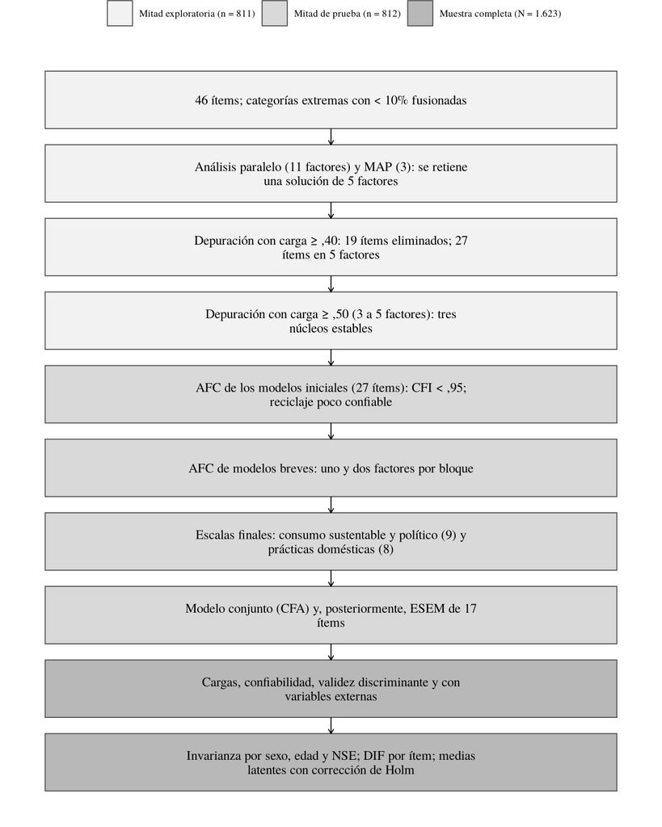

*Nota.* AFC = análisis factorial confirmatorio; ESEM = modelo exploratorio de ecuaciones estructurales; DIF = funcionamiento diferencial de los ítems; NSE = nivel socioeconómico. El ESEM, el análisis de DIF, las anclas alternativas, la corrección por comparaciones múltiples y los análisis de sensibilidad se agregaron después de los análisis originales. La Tabla S16 indica qué decisiones se especificaron antes de estimar los modelos en la mitad de prueba y cuáles después.

**Tabla S11**

*Funcionamiento Diferencial de los Interceptos por Nivel Socioeconómico y Sexo*

| Ítem | MI | ΔCFI | dMACS C2-C3 | dMACS D-E | Media D-E | MI sexo | dMACS mujer | Media mujer |
| --- | --- | --- | --- | --- | --- | --- | --- | --- |
| O2.11 | 3,1 | ,000 | ,09 | ,06 | −0,34 → −0,34 | 11,2 | ,11 | 0,00 → −0,04 |
| O2.12 | 6,3 | ,000 | ,14 | ,06 | −0,34 → −0,33 | 4,8 | ,08 | 0,00 → −0,03 |
| O3.4 | 6,8 | ,000 | ,01 | ,10 | −0,34 → −0,29 | 2,8 | ,06 | 0,00 → 0,03 |
| O3.7 | 7,9 | ,001 | ,18 | ,16 | −0,34 → −0,41 | 8,3 | ,09 | 0,00 → 0,04 |
| O3.2 | 2,5 | ,000 | ,11 | ,11 | −0,22 → −0,16 | 9,0 | ,11 | 0,01 → −0,04 |
| O3.3 | 19,3 | ,002 | ,26 | ,30 | −0,22 → −0,42 | 25,0 | ,17 | 0,01 → −0,07 |
| O3.5 | 13,4 | ,001 | ,16 | ,26 | −0,22 → −0,16 | 35,1 | ,19 | 0,01 → 0,07 |
| O3.8 | 1,2 | ,000 | ,07 | ,10 | −0,22 → −0,23 | 21,2 | ,20 | 0,01 → 0,03 |
| O3.9 | 5,3 | ,000 | ,13 | ,15 | −0,22 → −0,19 | 0,0 | ,04 | 0,01 → 0,01 |
| O2.1 | 0,1 | −,001 | ,07 | ,17 | 0,25 → 0,25 | 0,2 | ,03 | 0,11 → 0,11 |
| O2.2 | 2,3 | −,001 | ,07 | ,09 | 0,25 → 0,27 | 13,7 | ,13 | 0,11 → 0,08 |
| O2.3 | 1,5 | −,001 | ,07 | ,02 | 0,25 → 0,25 | 21,9 | ,16 | 0,11 → 0,19 |
| O2.4 | 31,8 | ,005 | ,09 | ,24 | 0,25 → 0,31 | 3,8 | ,10 | 0,11 → 0,10 |
| O2.5 | 25,2 | ,004 | ,17 | ,25 | 0,25 → 0,09 | 0,1 | ,02 | 0,11 → 0,10 |
| O1.10 | 0,1 | −,001 | ,02 | ,02 | −0,19 → −0,20 | 0,1 | ,01 | 0,15 → 0,14 |
| O2.8 | 13,9 | ,002 | ,17 | ,28 | −0,19 → −0,34 | 21,3 | ,19 | 0,15 → 0,04 |
| O2.9 | 20,9 | ,003 | ,12 | ,21 | −0,19 → −0,08 | 36,9 | ,16 | 0,15 → 0,23 |

*Nota.* Los nueve primeros ítems pertenecen a la escala de consumo sustentable y político, y los ocho restantes, a la de prácticas domésticas. Para cada ítem se liberó su intercepto en todos los grupos salvo el de referencia (ABC1; hombres), partiendo del modelo escalar. MI = suma de los índices de modificación del intercepto en el modelo escalar. ΔCFI = cambio en el CFI al liberarlo (NSE). dMACS = diferencia media en la puntuación esperada del ítem entre el grupo focal y el de referencia, a igual nivel del factor, ponderada por la distribución latente del grupo focal y dividida por la desviación estándar combinada del ítem; incluye las diferencias en las varianzas residuales, que el modelo escalar deja libres. Media = diferencia de medias latentes del factor del ítem (D-E vs. ABC1; mujeres vs. hombres) en el modelo escalar → al liberar el intercepto, en desviaciones estándar.

**Tabla S12**

*Diferencias de Medias Latentes por Edad según los Ítems Usados como Anclas*

| Factor | Tramo | Modelo publicado | Rango con anclas alternativas | Significativas (p < ,05) |
| --- | --- | --- | --- | --- |
| Compra sustentable | 35-54 vs. 18-34 | 0,15 | −0,02 a 0,23 | 4 de 6 |
|  | 55 o más vs. 18-34 | 0,36 | 0,22 a 0,44 | 6 de 6 |
| Consumo político | 35-54 vs. 18-34 | 0,15 | −0,29 a 0,31 | 5 de 10 |
|  | 55 o más vs. 18-34 | −0,08 | −0,50 a 0,07 | 5 de 10 |
| Ahorro doméstico | 35-54 vs. 18-34 | 0,57 | 0,03 a 0,71 | 7 de 10 |
|  | 55 o más vs. 18-34 | 1,25 | 0,23 a 1,40 | 10 de 10 |
| Planificación de compras | 35-54 vs. 18-34 | 0,09 | 0,06 a 0,12 | 0 de 3 |
|  | 55 o más vs. 18-34 | 0,25 | 0,24 a 0,25 | 3 de 3 |

*Nota.* En cada modelo, solo un par de ítems del factor mantuvo interceptos iguales entre tramos de edad (anclas) y se liberaron los demás; el otro factor de la escala conservó la especificación del modelo escalar parcial publicado. Diferencias en desviaciones estándar del tramo de 18 a 34 años.

**Tabla S13**

*Cargas Estandarizadas del Modelo Exploratorio de Ecuaciones Estructurales de 17 Ítems (Mitad de Prueba)*

| Ítem | Compra sustentable | Consumo político | Ahorro doméstico | Planificación de compras |
| --- | --- | --- | --- | --- |
| O2.11 | **,89** | −,23 | −,14 | ,05 |
| O2.12 | **,51** | ,09 | ,15 | ,06 |
| O3.4 | **,52** | ,27 | ,15 | −,08 |
| O3.7 | **,56** | ,10 | ,02 | ,04 |
| O3.2 | ,10 | **,61** | −,01 | ,00 |
| O3.3 | ,22 | **,62** | ,03 | ,00 |
| O3.5 | −,04 | **,61** | ,00 | ,09 |
| O3.8 | −,09 | **,83** | −,11 | ,03 |
| O3.9 | ,02 | **,62** | −,04 | −,04 |
| O2.1 | ,00 | −,12 | **,72** | ,02 |
| O2.2 | −,04 | ,03 | **,68** | ,00 |
| O2.3 | −,02 | ,07 | **,61** | ,05 |
| O2.4 | ,03 | −,17 | **,48** | ,09 |
| O2.5 | ,11 | ,03 | **,60** | −,03 |
| O1.10 | ,05 | ,03 | −,02 | **,61** |
| O2.8 | −,07 | −,05 | ,10 | **,84** |
| O2.9 | ,11 | ,13 | −,09 | **,47** |

*Nota.* Estimación WLSMV con rotación objetivo: las cargas cruzadas se orientaron hacia 0 y las principales (en negrita) quedaron libres. Correlaciones entre factores: compra sustentable con consumo político, ,54; con ahorro, ,39; con planificación, ,45; consumo político con ahorro, −,14; con planificación, ,11; ahorro con planificación, ,53.

**Tabla S14**

*Análisis de Sensibilidad: Calidad de las Respuestas y Categorías sin Colapsar*

| Análisis | Escala | n | CFI | TLI | RMSEA | SRMR | λ mín. | r factores |
| --- | --- | --- | --- | --- | --- | --- | --- | --- |
| Publicado (muestra completa) | Consumo sustentable y político | 1623 | ,971 | ,959 | ,061 | ,045 | ,59 | ,71 |
|  | Prácticas domésticas | 1623 | ,988 | ,983 | ,037 | ,029 | ,48 | ,59 |
| Sin casos de baja calidad (muestra completa) | Consumo sustentable y político | 1590 | ,972 | ,961 | ,058 | ,044 | ,57 | ,71 |
|  | Prácticas domésticas | 1590 | ,989 | ,984 | ,034 | ,028 | ,49 | ,59 |
| Publicado (mitad 2) | Consumo sustentable y político | 812 | ,968 | ,955 | ,063 | ,049 | ,58 | ,66 |
|  | Prácticas domésticas | 812 | ,995 | ,992 | ,025 | ,027 | ,42 | ,57 |
| Sin colapsar categorías (mitad 2) | Consumo sustentable y político | 812 | ,966 | ,952 | ,070 | ,046 | ,58 | ,67 |
|  | Prácticas domésticas | 812 | ,991 | ,987 | ,032 | ,028 | ,43 | ,57 |
| Sin colapsar categorías (muestra completa) | Consumo sustentable y político | 1623 | ,969 | ,957 | ,067 | ,041 | ,58 | ,73 |
|  | Prácticas domésticas | 1623 | ,988 | ,983 | ,038 | ,027 | ,50 | ,60 |

*Nota.* Casos de baja calidad: duración menor que un tercio de la mediana o respuesta en línea recta en dos o más de las baterías O1, O2 y O3 (33 casos). Sin colapsar: ítems con sus cinco categorías originales. λ mín. = carga estandarizada mínima; r factores = correlación entre los dos factores de la escala.

**Tabla S15**

*Correlaciones de los Factores con Indicadores de Situación Económica y Sensibilidad de la Posición Política*

| Variable | Compra sustentable | Consumo político | Ahorro doméstico | Planificación de compras |
| --- | --- | --- | --- | --- |
| Consumo como postura política, sin el valor 5 de posición política (n = 934) | ,07 [,00, ,14] | ,21 [,14, ,28]* | −,19 [−,26, −,11]* | −,03 [−,11, ,04] |
| Deuda para comprar alimentos (n = 1623) | −,06 [−,13, ,02] | ,01 [−,07, ,09] | −,03 [−,11, ,05] | ,02 [−,06, ,10] |
| Ingreso del hogar (n = 1450) | ,06 [,00, ,13]* | ,10 [,04, ,15]* | −,05 [−,11, ,01] | ,06 [,00, ,12] |
| Más endeudado que hace tres años (n = 1623) | −,05 [−,12, ,02] | ,02 [−,05, ,10] | −,05 [−,12, ,03] | −,04 [−,11, ,04] |
| Posición política (derecha), sin el valor 5 (n = 934) | −,10 [−,17, −,02]* | −,20 [−,27, −,12]* | −,01 [−,09, ,07] | ,05 [−,02, ,12] |

*Nota.* Correlaciones [IC 95%] entre cada factor y la variable externa, estimadas con WLSMV en un modelo que incluye la escala correspondiente. Ingreso: cinco tramos, tratado como continuo; se excluyó a quienes prefirieron no responder. Deuda para comprar alimentos: indicó “Supermercado/Alimentos” como primer o segundo motivo de sus deudas. Más endeudado: se declara más endeudado que tres años atrás. Ambas binarias, tratadas como ordinales. * *p* < ,05.

**Tabla S16**

*Registro de Decisiones del Análisis: Momento, Muestra y Carácter Confirmatorio o Exploratorio*

| Paso | Decisión | Base de la decisión | Muestra | Carácter |
| --- | --- | --- | --- | --- |
| 1 | Fusionar categorías extremas con menos del 10% de las respuestas | Distribución de las respuestas | Completa, antes de dividirla | Previa; filtración menor entre mitades |
| 2 | Dividir la muestra al azar en dos mitades | Validación cruzada | Completa | Previa |
| 3 | Retener cinco factores y depurar ítems con carga < ,40 o cargas cruzadas | Análisis paralelo, MAP e interpretabilidad | Exploratoria | Exploratoria |
| 4 | Comparar el modelo unidimensional (M1), la estructura exploratoria (M2) y su separación en compra sustentable y consumo político (M3) | Estructura exploratoria e hipótesis de la literatura | Prueba | **Especificada antes de estimar en la mitad de prueba** |
| 5 | Eliminar el ítem O4.6 (M4) | Índices de modificación de M3 | Prueba | Posterior a los resultados |
| 6 | Buscar escalas breves con carga ≥ ,50 | Ajuste insuficiente de M4 en la mitad de prueba | Exploratoria | Posterior; motivada por la mitad de prueba |
| 7 | Agregar O2.11 y O2.12 a la compra sustentable | Cargas en la solución exploratoria inicial | Exploratoria | Posterior |
| 8 | Elegir dos escalas de dos factores entre seis modelos breves | Ajuste en la mitad de prueba | Prueba | Posterior; selección en la mitad de prueba |
| 9 | Estimar el modelo conjunto y el ESEM | Desajuste del modelo conjunto | Prueba | Posterior |
| 10 | Evaluar la invarianza (configural, umbrales, métrica y escalar) con los criterios de Chen | Procedimiento estándar | Completa | Planificada, aplicada a escalas ya seleccionadas |
| 11 | Liberar los interceptos de O3.9, O2.2 y O2.5 por edad | Índices de modificación | Completa | Posterior a los resultados |
| 12 | Correlaciones con la lectura política del consumo, la posición política y la educación | Hipótesis de la literatura | Completa | Especificada tras seleccionar las escalas |
| 13 | Funcionamiento diferencial por ítem, corrección de Holm, anclas alternativas, indicadores económicos y análisis de sensibilidad | Revisión del manuscrito | Completa | Posterior a los resultados |

*Nota.* Reconstruido a partir del código de análisis, en el orden en que se ejecutaron los análisis. No hubo un plan de análisis registrado previamente. Muestra exploratoria: n = 811; muestra de prueba: n = 812. Solo el paso 4 constituye una comparación confirmatoria en sentido estricto: sus modelos se definieron antes de estimarlos en la mitad de prueba. Como los pasos 5 a 9 usaron la mitad de prueba para seleccionar y modificar modelos, la estructura final no se ha evaluado en datos independientes de su selección.